# ExamProject - Mapping the UN Treaties

Christian Lauritzen & Christoffer Brødsted

2023-12-22

The following code is made by inspiration of this project on similar mapping of data: https://www.sharpsightlabs.com/blog/map-talent-competitiveness/

Starting by reading in the Packages and libraries:

```r
library(tidyverse)
library(rvest)
library(magrittr)
library(ggmap)
```

```r
library(stringr)
library(maps)
library(dplyr)
library(ggplot2)
```

We start by getting our data from the United Nations Treaty Collection website and specifying exactly what part of the website data we want:

```r
UN_Data<- read_html("https://treaties.un.org/Pages/ViewDetails.aspx?src=TREATY&mtdsg_no=IV-1&chapter=4&clang=_en", na=c("NULL"))

UN_Data_raw <- UN_Data %>%
  html_nodes("table") %>%
  extract2(11) %>%
  html_table()
```

```r
view(UN_Data_raw)
```

We now have a tibble of the countries who have signed the treaty, signature dates for a few of the countries and when they signed it.

Before we go further with the UN_Data_raw, we are now going to grab the Map_data(“World”) which contains the base data for the final product and a list of all the countries in the world with that coordinates and specific data

```r
World_map <- map_data("world")
```

What we want to do is create a combined dataset combining the UN-Data_raw and our World_map, but before that we will adapt the UN_Data_raw to contain a value for the countries listed, we will use this later on. We do this by taking the “X3” category which had the date of the signatures and modify it to give all the countries a value of 1 We also rename the two categories we are going to use.

```r
UN_Data_final <- UN_Data_raw %>% select(X1, X3) %>% rename(country = X1, new_col = X3) %>%
  mutate(new_col=c(T))
```

Before we can join these two data sets together we first have to adapt some of the country names to fit with the names in Map_Data or else we would end up with a mess that wouldnt be able to be joined correctly. By having the two lists have an identical lists of countries it makes us able to use that list as a basis for joining the two data sets together. We do this by finding out all the countries that have a different name in the two data sets and change the names in UN_Data_final to fit with Map_data:

```r
UN_Data_final$country <- recode(UN_Data_final$country
                                   ,'United States of America' = 'USA'
                                   ,'United Kingdom' = 'UK'
                                   ,'Antigua and Barbuda'='Antigua'
                                   ,'Bolivia (Plurinational State of)'='Bolivia'
                                   , 'Czech Republic 4'='Czech Republic'
                                   , 'Germany 11, 12, 13'='Germany'
                                   , "Bosnia and Herzegovina 2, 4" = "Bosnia and Herzegovina"
                                   , "China 5, 6, 7" = "China"
                                   , "Côte d'Ivoire"='Ivory Coast'
                                   , 'Croatia 2'='Croatia'
                                   , "Holy See"="Vatican"
                                   , "Iran (Islamic Republic of)"="Iran"
                                   , "Netherlands (Kingdom of the)"="Netherlands"
                                   , "North Macedonia 2"="North Macedonia"
                                   , "Portugal 3"="Portugal"
                                   , "Republic of Moldova"="Moldova"
                                   , "Republic of Korea"="South Korea"
                                   , "Russian Federation"="Russia"
                                   , "Serbia 2"="Serbia"
                                   , "Slovakia 4"="Slovakia"
                                   , "Slovenia 2"="Slovenia"
                                   , "St. Kitts and Nevis"="Saint Kitts"
                                   , "St. Vincent and the Grenadines"="Saint Vincent"
                                   , "Sutiname 7"="Suriname"
                                   , "Trinidad and Tobago"="Trinidad"
                                   , "Tuvalu 8"="Tuvalu"
                                   , "Ukraine 9"="Ukraine"
                                   , "United Kingdom of Great Britain and Northern Ireland"="UK"
                                   , "Yemen 10"="Yemen"
                                   , "United Republic of Tanzania"="Tanzania"
                                   , "Congo"="Republic of Congo"
                                   , "Türkiye"="Turkey"
                                   , "Argentina 3" = "Argentina"
                                   , "Cuba 8" = "Cuba"
                                   , "Cyprus 9" = "Cyprus"
                                   , "Czech Republic 10" = "Czech Republic"
                                   , "Yemen 19" = "Yemen"
                                   , "Viet Nam 17, 18" = "Vietnam"
                                   , "Slovakia 10" = "Slovakia"
                                   , "Lao People's Democratic Republic" = "Laos"
                                   , "Montenegro 14" = "Montenegro"
                                   , "New Zealand 15" = "New Zealand"
                                   , "Democratic People's Republic of Korea" = "North Korea"
                                   , "Portugal 7" = "Portugal"
                                   , "Serbia 4, 16" = "Serbia"
                                   , "Venezuela (Bolivarian Republic of)" = "Venezuela"
                                   , "Syrian Arab Republic" = "Syria"
                                   , "State of Palenstine" = "Palenstine"
)
```

Now that we have two datasets which both have a country column where the country names are identical, we can now join the two datasets together into a combined one, by using the two country columns as the center:

```r
world_map_joined <- left_join(World_map, UN_Data_final, by = c('region' = 'country'))
```

Now we mutate the new data set to take advantage of the new “new_col” which is only applied to the countries from our UN data list. We mutate them to give every country that has a value in “new_col” to be labeled as TRUE and every country that isn’t as FALSE. By doing this we can now assign the two different kinds of countries different colors:

```r
world_map_joined <- world_map_joined %>%
  mutate(fill_flg = ifelse(is.na(new_col),F,T))
```

Now we can use the final, mutated world_map_joined to create our map:

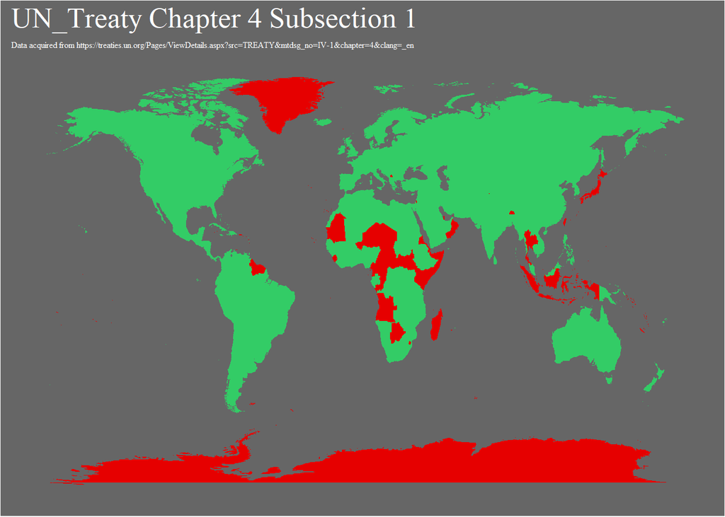

```r
ggplot() +
  geom_polygon(data = world_map_joined, aes(x = long, y = lat, group = group, fill = fill_flg)) +
  scale_fill_manual(values = c("#e60000","#33CC66")) +
  labs(title = 'UN_Treaty Chapter 4 Subsection 1'
       ,subtitle = "Data acquired from https://treaties.un.org/Pages/ViewDetails.aspx?src=TREATY&mtdsg_no=IV-1&chapter=4&clang=_en") +
  theme(text = element_text(family = "serif", color = "#FFFFFF")
        ,panel.background = element_rect(fill = "#666666")
        ,plot.background = element_rect(fill = "#666666")
        ,panel.grid = element_blank()
        ,plot.title = element_text(size = 20)
        ,plot.subtitle = element_text(size = 6)
        ,axis.text = element_blank()
        ,axis.title = element_blank()
        ,axis.ticks = element_blank()
        ,legend.position = "none")
```